# Causal Estimation, the Cross-Lagged Regression Model, and Authoritarianism: A Short Response to Luttig (2021)

## Introduction

In an age of heightened polarization – in which the political parties have grown more ideologically extreme and voters have sorted themselves into partisan camps following their ideological leanings – individual difference variables previously linked with voter behavior are now highly collinear with partisan identification. It is precisely this reason that establishing causal relationships using observational data are difficult to estimate. In a recent book, Federico, Feldman and Weber (2021) demonstrate that authoritarianism – the tendency to prioritize social conformity over personal autonomy – is now structured by party identification.

This finding extends prior work by Hetherington and Weiler (2009) whom argue that the ascendance of racial issues, law and order, feminism, and foreign affairs mobilized authoritarians to align themselves with the Republican party. Throughtout the 1990s and early 2000s, authoritarian voters defected en masse from the Democratic Party, a process that Federico et al (2021) and Inglehart and Norris (2018) describe as a component giving rise to Donald Trump’s authoritarian-inspired appeal.

One explanation for this departure of common wisdom regarding authoritarianism may be due to the nature of the authoritarianism scale, as measured by the Child Rearing Questionnaire (CRQ). The CRQ is a 4-item scale that asks respondents to choose between two competing values. While conceivable, it is difficult to imagine how a respondent’s preference for “independence” or “respect for elders,” or “obedience” versus “self-reliance: in children could be endogenous to their party preference. While this is plausible, the CRQ was developed precisely because of the well-argued and researched claim that measures of authoritarianism, like”Right-Wing Authoritarianism” (Altemeyer 1981) and the “Fascism (F) - Scale” (Adorno et al 1950) clearly reference political content. In the case of the CRQ, it was developed to measure authoritarianism without political content. Luttig’s argument rests on a cueing process, whereby partisanship coalesces with exposure to like minded partisan elites, who may present authoritarian ideas. While this is a plausible explanation in a general sense – some elites advocating authoritarianism – it less plausible in the specific sense of the CRQ. The CRQ is not a measure of authoritarianism per se, but rather a measure of **child rearing preferences**.

In this short piece, we reconsider Luttig’s findings using causal diagrams to generate various causal estimands. We argue that Luttig’s findings do not adequately capture the complicated relationship between authoritarianism and its political expression. Yet, the problem does not solely reside in misplaced theory or particular data, but rather in the statistical method to identify causal processes, the Cross-Lagged Regression Model. As we will show, causal inference can be accomplished using these and similar data, but inference rests with careful theoretical reasoning about the data generating process, and the use of causal diagrams, not a data-driven appraoch commonly relied upon the the CLR.

# The Cross Lagged Regression Model

It is difficult to sort out causal mechanisms with cross-sectional observational data. It is also difficult to sort out causal mechanisms with panel data. Causal relationships require theorizing about the data generating process. Data, particularly when observational, and statistical procedures do not guarantee that researcher will identify a causal mechanism.

```r
suppressMessages(library(dplyr))
suppressMessages(library(haven))
suppressMessages(library(dagitty))
suppressMessages(library(ggdag))
suppressMessages(library(ggplot2))
```

Consider the well-known Cross-Lagged Regression model (CLR).

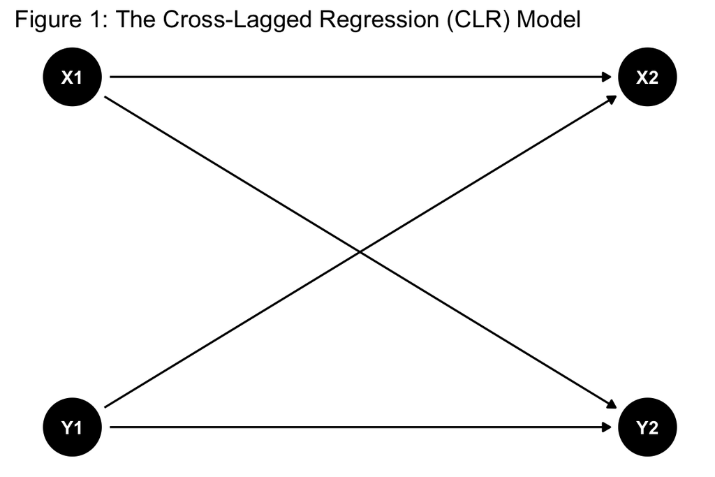

```r
options(repr.plot.width = 2, repr.plot.height = 2)  # Set smaller plot size
g <- dagitty("dag {
    X1 -> Y2
    Y1 -> Y2
    X1 -> X2
    Y1 -> X2

}")
coordinates(g) <- list(
    x=c(U1=0.5, Y1=1,X1=1,Y2=2,X2=2, U2=3),
    y=c(U1=1.5, Y1=1,X1=2,Y2=1,X2=2, U2=2.5) )
ggdag(g, text = TRUE) + theme_dag() + ggtitle("Figure 1: The Cross-Lagged Regression (CLR) Model")
```

This is a case of a Directed Acyclic Graph (DAG; Pearl 2001), as the panel structure is temporal, and the arrows are directed. The CLR is a common method to test competing causal processes. The CLR is a special case of the more general Autoregressive Distributed Lag model used in econometrics. Because there are two dependent variables, party and authoritarianism, it is common to then estimate two regression models, one with $x$ as a dependent variable, the other with $y$ as the dependent variable.

$$\begin{eqnarray}
y_{t=2, i}=a_0 + a_1 y_{t=1, i} + a_2 x_{t=1, i} + e_{1,i} \hspace{1in}
(1)\\
x_{t=2, i}=b_0 + b_1 y_{t=1, i} + b_2 x_{t=1, i} + e_{2,i} \hspace{1in}
(2)\\
\end{eqnarray}$$

There are two issues that arise upon estimating this model. The first pertains to the empirical consequence of including a lagged realization of the independent variable in the regression model; the the second issue pertains to inclusion of a lagged dependent variable (Allison 1990).

Beginning with the independent variable, consider why one includes a lag and not the contemporaneous effect of $x_{2}$ on $y_{2}$ (and vice-versa). Causal inference is challenging with observational cross-sectional data, due to the researcher’s inability to control for the effect of confounding covariates. This is why correct model specification is necessary. The **contemporaneous causal** effect cannot be reliably estimated because it is likely confounded by unobservable variables. It is tempting to leverage the temporal nature of the data to estimate a lagged causal effect in place of the contemporaneous causal effect.

Yet, Bellamare et al (2017) notes that a lagged realization of the independent variable does not necessarily improve one’s ability to identify a causal effect. Instead, it moves the problem to identifying a lagged causal effect, effectively ignoring causal mechanisms that operate contemporaneously. Likewise, the inclusion of a lagged dependent variable is also problematic, for reasons well-documented in the literature (see Allison 1990). Introductory statistics textbooks present it in the context of autocorrelation, whereby including a lagged realization of the dependent variable will correlate with the error terms in equations (1) and (2), subsequently biasing parameter estimates and standard errors.

These problems can be particularly pernicious and difficult to resolve with two-wave panel designs (Hamaker, Kuipers and Grasman (2015). In particular, when variables in the model are stable, which is most certainly the case with authoritarianism and party/candidate evaluation, it becomes increasingly difficult to identify causal effects. For this reason, scholars have increasingly moved to adopting the Random-Intercept Cross-Lagged panel regression model (RI-CLPM), in which the paramters in equation (1) and (2) are estimated, but the intercept terms randomly vary across units, accounting for with-person variation. Unfortunately, this technique is only available when more than two-waves of panel data are available, a circumstance that does not apply to Luttig (2021).

# Causal Inference using Directed Acyclic Graphs

Identitying causal effects with observational data is difficult due to the presence of confounding variables. The problem is not limited to cross-sectional data, and also apply to observational panel data (though occasionally for different reasons). Consider the causal diagram in Figure 2, a slight modification on the CLR model presented in Figure 1. In this case, we have added a confounder set $U$ that is correlated with both $x_1$ and $y_1$, as well as $x_2$ and $y_2$.

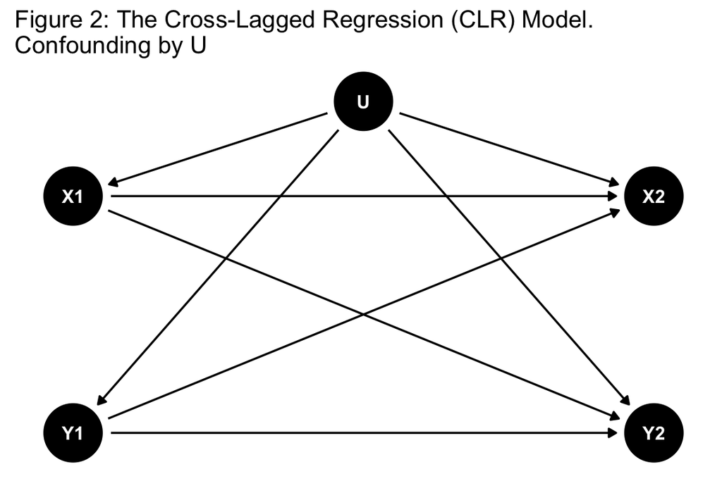

```r
g <- dagitty("dag {
    X1 -> Y2
    Y1 -> Y2
    X1 -> X2
    Y1 -> X2
    U -> X1
    U -> Y1
    U -> X2
    U -> Y2
    U <-> U
}")
coordinates(g) <- list(
    x=c( Y1=1,X1=1,Y2=2,X2=2, U=1.5),
    y=c( Y1=1,X1=2,Y2=1,X2=2, U=2.4) )
ggdag(g, text = TRUE) + theme_dag() + ggtitle("Figure 2: The Cross-Lagged Regression (CLR) Model.\nConfounding by U")
```

In this case, the confounder set creates a “backdoor path” from U to $x_2$ and $y_2$ through $x_1$ and $y_1$. Ignoring the confounder set $U$ will bias the estimates of the coefficients estimated in the model; this is the notion of “spurious regression” whereby we may even estimate a relationship when none exist.

The figure below demonstrates that including the confounder set $U$ blocks the backdoor path from $x_2$ to $y_2$ through $x_1$ and $y_1$.

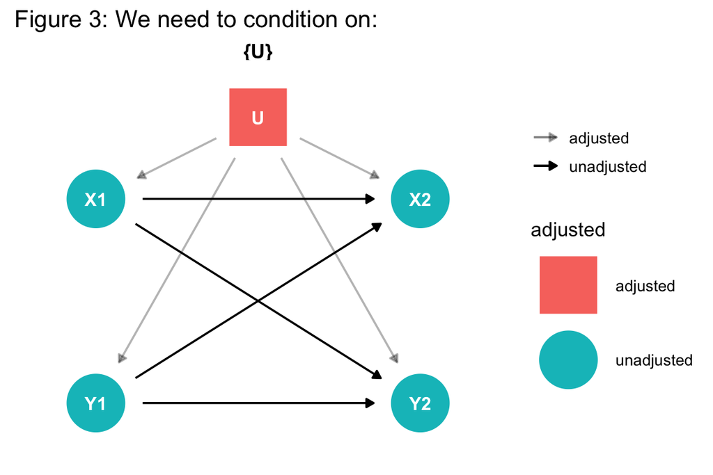

```r
ggdag_adjustment_set(g, exposure = "Y1", outcome = "Y2", shadow = "TRUE") + theme_dag() + ggtitle("Figure 3: We need to condition on:")
```

But what if prior research indicates that $U$ isn’t a common cause of both $x$ and $y$, but rather a cause of $y$. Also, assume a causal arrow between $x_1$ and $y_1$ and $x_2$ and $y_2$? This is contemporaneous causal correlation, which is not absent from data because a temporal component is specified. So, we also draw an arrow from $x_1 \rightarrow y_1$ and $x_2 \rightarrow y_2$.

Now the causal diagram becomes:

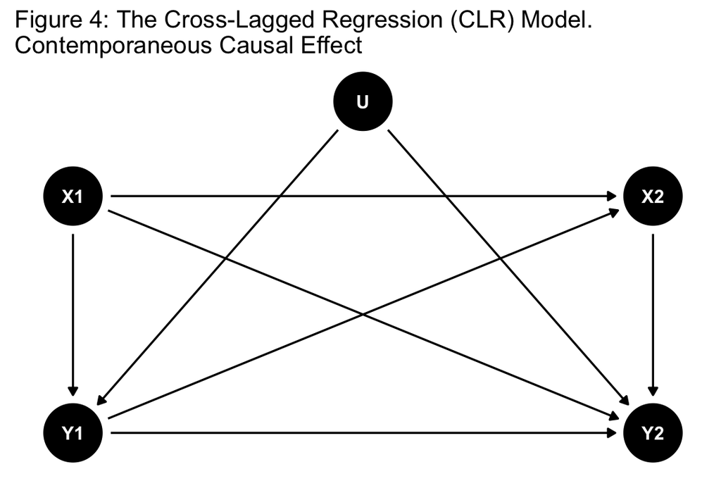

```r
g <- dagitty("dag {
    X1 -> Y2
    X2 -> Y2
    Y1 -> Y2
    X1 -> X2
    Y1 -> X2
    U -> Y1
    U -> Y2
    X1 -> Y1
}")
coordinates(g) <- list(
    x=c( Y1=1,X1=1,Y2=2,X2=2, U=1.5),
    y=c( Y1=1,X1=2,Y2=1,X2=2, U=2.4) )
ggdag(g, text = TRUE) + theme_dag() + ggtitle("Figure 4: The Cross-Lagged Regression (CLR) Model.\nContemporaneous Causal Effect")
```

In this case, the problem is somewhat different. $y_1$ and $y_2$ are “colliders” in the model, and conditioning on $y_1$ – the lag – will open a backdoor path from $U$ to $y_2$ and $x_2$, a problem known as “collider bias” (Pearl 2001). In this case, we are better served by excluding $y_1$ from the estimated equation, adopting a simpler model, $y_2 = \beta_1 x_1 + \epsilon$.

### Emprical Problems

Analysts who use the CLR attempt to sidestep contemporaneous causality – a difficult to defend concept when using observational data – by using lagged effects. The idea is relatively simple and elegant: if we measure $x$ at time $t$ and $y$ at time $t+1$, then we can be confident that $x$ is not caused by $y$. Any effect of of $x$ that precedes $y$ must be causal. While this may appear reasonable at face-value, it may be fallacious for several reasons.

### Contemporaneous Causal Effects

[figure not shown]

```r
g <- dagitty("dag {
    X1 -> Y2
    X1 -> Y1[style=dashed]
    Y1 -> Y2
    X1 -> X2
    Y1 -> X2
    X2 -> Y2

}")
coordinates(g) <- list(
    x=c( Y1=1,X1=1,Y2=2,X2=2, U=1.5),
    y=c( Y1=1,X1=2,Y2=1,X2=2, U=2.4) )
ggdag(g, text = TRUE) + theme_dag() + ggtitle("Figure XX: The Cross-Lagged Regression (CLR) Model.\nContemporaneous Causal Effect")
```

There is nothing inherently problematic about this causal effect. But the CLR in this circumstance is capturing an effect that does not necessarily comport to what Luttig (2021) describes. By conditioning on both $X1$ and $Y1$ though, we are not obtaining the total effect of $X1$ on $Y2$. Instead, we are capturing the **direct effect** of $X1$ on $Y2$ after accounting for $Y2$, and where $Y2$ mediates the relationship. $Y1$ is an intervening, mediating variable; it structures the effect of $X1$. Put another way, $X1$ may in fact have a rather large and substantial effect on $X2$. If we think that authoritarianism does not directly influence party evaluations at time $t+1$ because its effects are mediated by party evaluations at time $t$, then we are not capturing the total effect of authoritarianism on party evaluations in the CLR. In fact, this story is largely consistent with Federico, Feldman and Weber (2023) who show that authoritarianism does not have direct effects in many circumstances, precisely because authoritarians have sorted themselves into partisan camps and have adopted a partisan lens in which the world is viewed.

The problem, however, is when unobserved variables also predict $Y1$. Such is the case below,

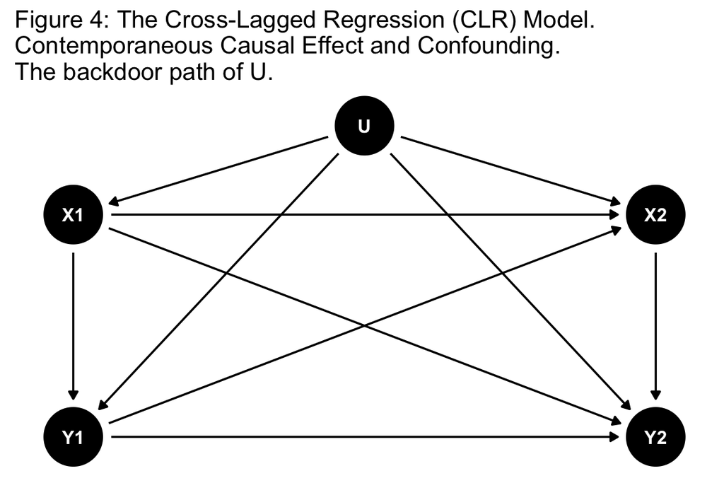

```r
g <- dagitty("dag {
    X1 -> Y2
    X2 -> Y2
    Y1 -> Y2
    X1 -> X2
    Y1 -> X2
    U -> Y1
    U -> Y2
    U -> X1
    U -> X2
    X1 -> Y1
}")
coordinates(g) <- list(
    x=c( Y1=1,X1=1,Y2=2,X2=2, U=1.5),
    y=c( Y1=1,X1=2,Y2=1,X2=2, U=2.4) )
ggdag(g, text = TRUE) + theme_dag() + ggtitle("Figure 4: The Cross-Lagged Regression (CLR) Model.\nContemporaneous Causal Effect and Confounding.\nThe backdoor path of U.")
```

The problem is now not just in interpretation, but also estimation. Adding a causal arrow from U to Y1 and Y2, we have a confounding variable. And this confounding variable creates a bias in the CLR model. By conditioning on $Y1$ – a collider – we open a backdoor path from $U$ to $Y2$ and $X2$. The effect of these variables, along with authoritarianism are captured in the estimated coefficient. This, however, is clearly not what we want. We would like to know the effect of authoritarianism on party evaluations, not the effect of authoritarianism, $Y1$ and $U$ on party evaluations. This is case of “m-bias”, because we are conditioning on an effect that is a consequence of $X1$ but also unbobserved variables $U$. The CLR model will estimate the effect of $X1$ on $Y2$, but it will be an incorrect estimate. The bias will bend in the direction of the confounding variable in relation to the observed variables. If $U$ is positively correlated with $X1$ and $Y2$, then the CLR will overestimate the effect of $X1$ on $Y2$. If $U$ is negatively correlated with $X1$ and $Y2$, then the CLR will underestimate the effect of $X1$ on $Y2$. In either case, the CLR will be biased.

This problem is well-established in the causal effects literature, as it represents the potentially problematic consequences of conditioning on a post-treatment variable, in this case, $Y1$, since $X1 \rightarrow Y1$. If other variables are left unspecified, then this “conditioning” exercise gives misleading results.

Together, not only must we consider the types of effects in our model – a matter of interpretation – we must also reason about the underlying causal structure in the data. Failing to consider the unobervable data may undermine our ability to accurately estimate both indirect and direct effects.

### Lagged Effects

Let us assume there are no contemporaneous causal effects, and the CLR is generally correctly specified, wherein the only causal parameters are lagged effects. Figure 1, in other words, accurately captures the causal structure of the data. The assumption of the model is that $X1$ and $y1$ are exogeneous: They both predict $Y2$ but do not predict each other. This is generally implausible. Imagine a circumstance, for instance, where we were to observe an additional wave of panel data, where,

[figure not shown]

```r
g <- dagitty("dag {
    X1 -> Y2
    Y1 -> Y2
    X1 -> X2
    Y1 -> X2
    X0 -> X1 [color=gray]
    Y0 -> Y1 [color=gray]
    X0 -> Y1 [color=gray]
    Y0 -> X1 [color=gray]
}")

coordinates(g) <- list(
    x=c( Y0 = 0, X0 = 0, Y1=1,X1=1,Y2=2,X2=2, U=1.5),
    y=c(Y0 = 1, X0 = 2, Y1=1,X1=2,Y2=1,X2=2, U=2.4) )

ggdag(g, text = TRUE) + theme_dag() + ggtitle("Figure 4: The Cross-Lagged Regression (CLR) Model.\nContemporaneous Causal Effect and Confounding.\nThe backdoor path of U.")
```

The idea is that the lagged variable is measured prior to the outcome variable, and thus the lagged variable cannot be caused by the outcome variable. This is the logic of the CLR model, and the reason why the CLR model is often used in panel data settings.

## Data, Models and Estimation

As Luttig notes:

**But previous analyses of the authoritarian divide separating Republicans from Democrats, and Trump supporters from opponents, rest primarily on correlational analyses that are unable to determine whether authoritarianism shapes partisan preferences, or whether political attitudes may instead shape how respondents answer the authoritarianism questionnaire. This is problematic, as recent research raises questions about the validity, over-time stability, and exogeneity of the child rearing measure of authoritarianism** (Luttig, 2021, 3).

We will show that more careful reasoning about the data and CLR necessitates a reconsideration of Luttig’s findings.

There are three datasets, all located in /data

- /data/panel_data.2016.rda. This is the 2016-2020 ANES
- /data/dataverse_files/merge201214nes.dta This is the 2012-13 ANES reported in Luttig (2021)
- /data/dataverse_files/2016 panel study.dta This is the SSI data reported in Luttig (2021)

/data/dataverse_files/ also includes Luttig’s (2021) replication code.

## Replication of Luttig (2021)

Models and simulations are included in /models

## Simulate Data

Assume this model, where Z represent a set of exogenous covariates, and U represents a set of unobserved confounders.

[figure not shown]

```r
g <- dagitty("dag {
    X1 -> Y2
    Y1 -> Y2
    Z  -> Y2 [color=gray]
    Z  -> Y1 [color=gray]
    Z  -> X1 [color=gray]
    U  -> Y2 [color=gray]
    U  -> Y1 [color=gray]
    U  -> X1 [color=gray]

    }")

coordinates(g) <- list(
    x=c(Z = 0,  Y1=1,X1=1,Y2=2, U=2.5),
    y=c(Z = 0,  Y1=1,X1=2,Y2=1, U=2) )

ggdag(g, text = TRUE) + theme_dag() + ggtitle("Figure 4: The Cross-Lagged Regression (CLR) Model.\nContemporaneous Causal Effect and Confounding.\nThe backdoor path of U.")
```

Conditioning on Y1 or X1 opens a backdoor path from U to Y2. The structural model:

$$\begin{eqnarray}
y_{1, i}= a_1 z_{i} + a_2 u_{i} + e_{1,i} \hspace{1in} (1)\\
x_{1, i}= b_1 z_{i} + b_2 u_{i} + e_{2,i} \hspace{1in} (2)\\
y_{2, i}= c_1 y_{1, i} + c_2 x_{1, i} + c_3 z_{i} + c_4 u_{i}
+ e_{3,i} \hspace{1in} (3)\\
\end{eqnarray}$$